# Report - Exam Group 7

Elaheh Javadi Arjmand, Ane Helland, Sigurd Mydske, Stand Hiestand

2024-09-12

## Data Source

Amy S. Nowacki, ‘Laryngoscope Dataset’, TSHS Resources Portal (2017). Available at https://www.causeweb.org/tshs/laryngoscope/

Data and description taken from [medicaldata webpage](https://higgi13425.github.io/medicaldata/reference/laryngoscope.html).

This data set contains 99 adult patients with a body mass index between 30 and 50 kg/m2 who required orotracheal intubation for elective surgery. Patient demographics, airway assessment data, intubation success rate, time to intubation, ease of intubation, and occurrence of complications were recorded.

## Working progress

This report will provide a day-to-day report of the work progress by our group.

#### Day 5

On this day, we created an initial script which would read the exam dataset described over, and started to explore it using the head, tail and glimpse-functions. We also removed duplicate entries. We also separated some values containing multiple points of information, and cleaned up the name of the columns. The data at the end of the day looked like this:

```
## Rows: 99
## Columns: 16
## $ id                     <dbl> 1, 2, 3, 4, 5, 6, 7, 8, 9, 10, 11, 12, 13, 14, …
## $ month                  <dbl> 4, 7, 10, 11, 2, 1, 5, 7, 9, 3, 10, 2, 3, 4, 3,…
## $ year                   <dbl> 2012, 2009, 2012, 2010, 2009, 2009, 2012, 2011,…
## $ age                    <dbl> 51, 52, 37, 20, 35, 39, 52, 59, 32, 24, 45, 29,…
## $ bmi                    <dbl> 56.20, 44.60, 41.60, 46.32, 61.00, 44.00, 44.00…
## $ randomization          <dbl> 0, 0, 0, 0, 0, 0, 0, 0, 0, 0, 0, 0, 0, 0, 0, 0,…
## $ attempts               <dbl> 1, 1, 2, 2, 1, 1, 1, 1, 1, 1, 1, 1, 1, 1, 1, 1,…
## $ failures               <dbl> 0, 0, 1, 1, 0, 0, 0, 0, 0, 0, 0, 0, 0, 0, 0, 0,…
## $ total_intubation_time  <dbl> 29.00, 29.00, 91.00, 77.00, 21.00, 10.00, 13.00…
## $ intubation_overall_S_F <dbl> 1, 1, 1, 1, 1, 1, 1, 1, 1, 1, 1, 1, 1, 1, 1, 1,…
## $ view                   <dbl> 1, 1, 0, 0, 1, 1, 1, 1, 1, 1, 1, 1, 1, 1, 0, 0,…
## $ intubation_method      <dbl> 0, 0, 0, 0, 0, 0, 0, 0, 0, 0, 0, 0, 0, 0, 0, 0,…
## $ intubation_success     <dbl> 1, 1, 1, 1, 1, 1, 1, 1, 1, 1, 1, 1, 1, 1, 1, 1,…
## $ bleeding               <dbl> 0, 0, 0, 0, 0, 0, 0, 0, 0, 0, 0, 0, 0, 0, 0, 0,…
## $ ease                   <dbl> 5, 20, 80, 80, 20, 2, 10, 60, 15, 0, 70, 85, 10…
## $ sore_throat            <dbl> 0, 0, 0, NA, 0, 0, 1, 0, 2, 1, 0, 3, 0, 0, 1, 0…
```

It obviously needed further wrangling to enable efficient analysis.

#### Day 6

```
## Rows: 109
## Columns: 23
## $ id                     <dbl> 1, 2, 3, 4, 5, 6, 6, 7, 8, 9, 9, 10, 11, 12, 13…
## $ gender                 <dbl> 0, 0, 0, 0, 0, 0, 0, 0, 0, 0, 0, 0, 0, 0, 1, 1,…
## $ age                    <dbl> 51, 52, 37, 20, 35, 39, 39, 52, 59, 32, 32, 24,…
## $ month                  <dbl> 4, 7, 10, 11, 2, 1, 1, 5, 7, 9, 9, 3, 10, 2, 3,…
## $ year                   <dbl> 2012, 2009, 2012, 2010, 2009, 2009, 2009, 2012,…
## $ bmi                    <dbl> 56.20, 44.60, 41.60, 46.32, 61.00, 44.00, 44.00…
## $ randomization          <dbl> 0, 0, 0, 0, 0, 0, 0, 0, 0, 0, 0, 0, 0, 0, 0, 0,…
## $ attempts               <dbl> 1, 1, 2, 2, 1, 1, 1, 1, 1, 1, 1, 1, 1, 1, 1, 1,…
## $ failures               <dbl> 0, 0, 1, 1, 0, 0, 0, 0, 0, 0, 0, 0, 0, 0, 0, 0,…
## $ total_intubation_time  <dbl> 29.00, 29.00, 91.00, 77.00, 21.00, 10.00, 10.00…
## $ intubation_overall_S_F <dbl> 1, 1, 1, 1, 1, 1, 1, 1, 1, 1, 1, 1, 1, 1, 1, 1,…
## $ view                   <dbl> 1, 1, 0, 0, 1, 1, 1, 1, 1, 1, 1, 1, 1, 1, 1, 1,…
## $ intubation_method      <dbl> 0, 0, 0, 0, 0, 0, 0, 0, 0, 0, 0, 0, 0, 0, 0, 0,…
## $ intubation_success     <dbl> 1, 1, 1, 1, 1, 1, 1, 1, 1, 1, 1, 1, 1, 1, 1, 1,…
## $ bleeding               <dbl> 0, 0, 0, 0, 0, 0, 0, 0, 0, 0, 0, 0, 0, 0, 0, 0,…
## $ ease                   <dbl> 5, 20, 80, 80, 20, 2, 2, 10, 60, 15, 15, 0, 70,…
## $ sore_throat            <dbl> 0, 0, 0, NA, 0, 0, 0, 1, 0, 2, 2, 1, 0, 3, 0, 0…
## $ asa                    <dbl> 3, 3, 3, 3, 3, 3, 3, 3, 3, 3, 3, 3, 2, 3, 3, 3,…
## $ Mallampati             <dbl> 1, 2, 1, 2, 2, 2, 2, 2, 2, 1, 1, 1, 1, 1, 3, 3,…
## $ gender_characters      <chr> "Female", "Female", "Female", "Female", "Female…
## $ mallampati_times_asa   <dbl> 3, 6, 3, 6, 6, 6, 6, 6, 6, 3, 3, 3, 2, 3, 9, 9,…
## $ ease_quartile          <chr> "(-0.1,25]", "(-0.1,25]", "(75,100]", "(75,100]…
## $ conformity_rand_int    <lgl> TRUE, TRUE, TRUE, TRUE, TRUE, TRUE, TRUE, TRUE,…
```

Here we have wrangled several additional variables from the original dataset.

#### Day 7

We experimented with graphical visualization of our data using ggplot. Here is an example of a geom_point with and without a regression line.

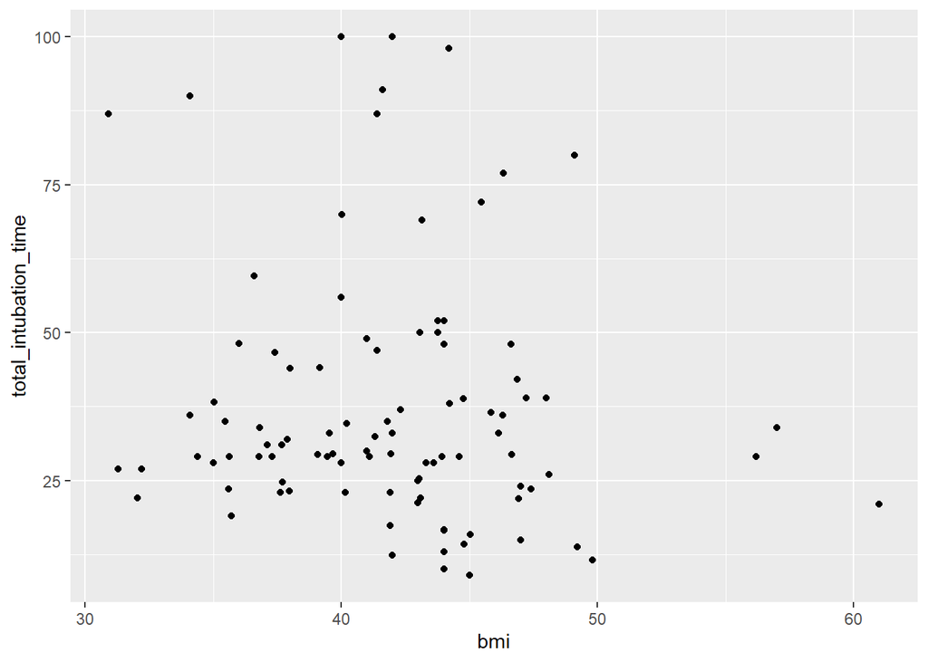

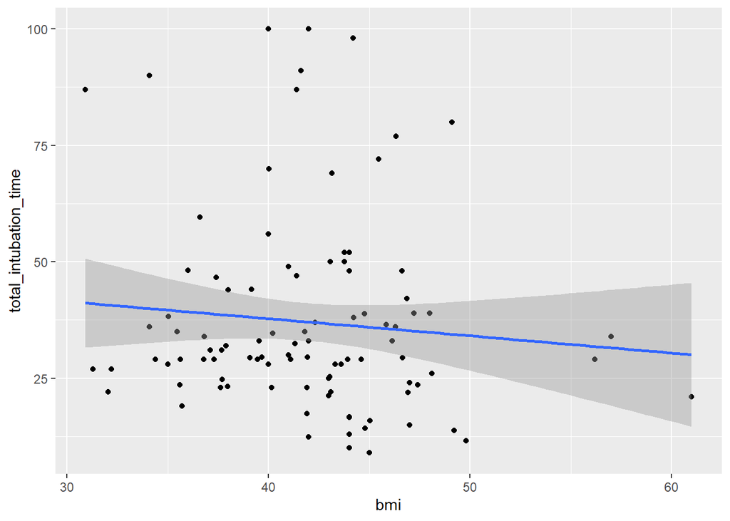

This shows the correlation between BMI and Total intubation time.

#### Day 8

We started to use simple statistical analysis, for example using a t-test for difference in means in gender groups

```r
t_test_result <-
  myData_columns %>%
    t.test(total_intubation_time~gender, data=.)
print(t_test_result)
```

```
##
##  Welch Two Sample t-test
##
## data:  total_intubation_time by gender
## t = -2.9441, df = 28.373, p-value = 0.006398
## alternative hypothesis: true difference in means between group 0 and group 1 is not equal to 0
## 95 percent confidence interval:
##  -28.04284  -5.03909
## sample estimates:
## mean in group 0 mean in group 1
##        33.68686        50.22783
```

p-value= 0.0063, there is a difference in mean total intubation time between gender groups. mean total intubation time for males= 50.22 and for females= 33.68